# Aussie Rain

Jim Greene

3/8/2021

Return

# Introduction

I demonstrate improved binary classification by piping the results of a neural network into a local regression model (LOESS).

The data used is from the [Rain in Australia](https://www.kaggle.com/jsphyg/weather-dataset-rattle-package) project on Kaggle. View the link to see the structure and appearance of the data. What I do here is unique to what others have done and expands on the data manipulation (wrangling).

The primary challenge is to predict if the next day will experience more than 1mm of rain, given the information of the previous day.

It is possible to create another model that uses more days to predict the upcoming days. I could use a time series prediction approach similar to what I tried with the stock market. But I’m done playing with this dataset; there is more to explore.

From this exercise, I learned more about iterative imputation and improved my skills with deep learning.

# Exploration

I’ve foregone a clean example script for the exploration I performed. Important facts include that there are lots of values missing not at random, highly dependent on the weather station (Location) they came from. The observations where Rainfall is missing are identical to the ones with RainToday missing.

# Manipulation

This is the script used in preparation for use with the neural network:

```r
# Change of plans for prediction: Going to use black box models.
#
# I first used logistic regression models, but they were massive models and I
# decided it would be easier to switch to a neural network. The classical
# regression models were uninterpretable anyway, with hundreds of terms.
# (I could have also used a random forest, XGBoost, or similar.)

library(tidyverse)
library(lubridate)
library(mice)

# guess_max solves the issue of incorrect column type assignments.
rain <- read_csv("weatherAUS.csv", guess_max = 10000)

rain <- rain %>%
  # Deriving periodic day of the year with trigonometric transformations
  # and ignoring other aspects of the date, like the year.
  mutate(Year = year(Date),
         Day = yday(Date)) %>%
  mutate(DateAngle = if_else(Year %% 4 == 0, Day/366, Day/365) * 2*pi) %>%
  mutate(DateSine = sin(DateAngle),
         DateCosine = cos(DateAngle)) %>%
  select(-DateAngle, -Day, -Date, -Year) %>%
  # Sunshine is almost 50% missing values, and not at random.
  # Previously I removed it entirely with "select(-Sunshine) %>%",
  # but this time I'll keep.
  #
  # Converting wind directions with similar periodic transformations
  mutate(
    WindGustSine = case_when(
      WindGustDir == "N" ~ 1,
      WindGustDir == "S" ~ -1,
      WindGustDir %in% c("W", "E") ~ 0,
      WindGustDir %in% c("NW", "NE") ~ sin(pi/4),
      WindGustDir %in% c("SW", "SE") ~ sin(-pi/4),
      WindGustDir %in% c("NNW", "NNE") ~ sin(3*pi/8),
      WindGustDir %in% c("SSW", "SSE") ~ sin(-3*pi/8),
      WindGustDir %in% c("WNW", "ENE") ~ sin(pi/8),
      WindGustDir %in% c("WSW", "ESE") ~ sin(-pi/8)
    ),
    WindGustCosine = case_when(
      WindGustDir %in% c("N", "S") ~ 0,
      WindGustDir == "W" ~ -1,
      WindGustDir == "E" ~ 1,
      WindGustDir %in% c("NW", "SW") ~ cos(3*pi/4),
      WindGustDir %in% c("NE", "SE") ~ cos(pi/4),
      WindGustDir %in% c("NNW", "SSW") ~ cos(5*pi/8),
      WindGustDir %in% c("NNE", "SSE") ~ cos(3*pi/8),
      WindGustDir %in% c("WNW", "WSW") ~ cos(7*pi/8),
      WindGustDir %in% c("ENE", "ESE") ~ cos(pi/8)
    ),
    WindSine9am = case_when(
      WindDir9am == "N" ~ 1,
      WindDir9am == "S" ~ -1,
      WindDir9am %in% c("W", "E") ~ 0,
      WindDir9am %in% c("NW", "NE") ~ sin(pi/4),
      WindDir9am %in% c("SW", "SE") ~ sin(-pi/4),
      WindDir9am %in% c("NNW", "NNE") ~ sin(3*pi/8),
      WindDir9am %in% c("SSW", "SSE") ~ sin(-3*pi/8),
      WindDir9am %in% c("WNW", "ENE") ~ sin(pi/8),
      WindDir9am %in% c("WSW", "ESE") ~ sin(-pi/8)
    ),
    WindCosine9am = case_when(
      WindDir9am %in% c("N", "S") ~ 0,
      WindDir9am == "W" ~ -1,
      WindDir9am == "E" ~ 1,
      WindDir9am %in% c("NW", "SW") ~ cos(3*pi/4),
      WindDir9am %in% c("NE", "SE") ~ cos(pi/4),
      WindDir9am %in% c("NNW", "SSW") ~ cos(5*pi/8),
      WindDir9am %in% c("NNE", "SSE") ~ cos(3*pi/8),
      WindDir9am %in% c("WNW", "WSW") ~ cos(7*pi/8),
      WindDir9am %in% c("ENE", "ESE") ~ cos(pi/8)
    ),
    WindSine3pm = case_when(
      WindDir3pm == "N" ~ 1,
      WindDir3pm == "S" ~ -1,
      WindDir3pm %in% c("W", "E") ~ 0,
      WindDir3pm %in% c("NW", "NE") ~ sin(pi/4),
      WindDir3pm %in% c("SW", "SE") ~ sin(-pi/4),
      WindDir3pm %in% c("NNW", "NNE") ~ sin(3*pi/8),
      WindDir3pm %in% c("SSW", "SSE") ~ sin(-3*pi/8),
      WindDir3pm %in% c("WNW", "ENE") ~ sin(pi/8),
      WindDir3pm %in% c("WSW", "ESE") ~ sin(-pi/8)
    ),
    WindCosine3pm = case_when(
      WindDir3pm %in% c("N", "S") ~ 0,
      WindDir3pm == "W" ~ -1,
      WindDir3pm == "E" ~ 1,
      WindDir3pm %in% c("NW", "SW") ~ cos(3*pi/4),
      WindDir3pm %in% c("NE", "SE") ~ cos(pi/4),
      WindDir3pm %in% c("NNW", "SSW") ~ cos(5*pi/8),
      WindDir3pm %in% c("NNE", "SSE") ~ cos(3*pi/8),
      WindDir3pm %in% c("WNW", "WSW") ~ cos(7*pi/8),
      WindDir3pm %in% c("ENE", "ESE") ~ cos(pi/8)
    )
  ) %>%
  select(-c(WindGustDir, WindDir9am, WindDir3pm)) %>%
  # Making location a quantitative feature.
  # This requires a more complicated response surface than one-hot encoding,
  # but (might) provide better results in the long run.
  mutate(
    Lat = case_when(
      Location == "Albury" ~ -36.0737,
      Location == "BadgerysCreek" ~ -33.8829,
      Location == "Cobar" ~ -31.4958,
      Location == "CoffsHarbour" ~ -30.2986,
      Location == "Moree" ~ -29.4658,
      Location == "Newcastle" ~ -32.9283,
      Location == "NorahHead" ~ -33.2833,
      Location == "NorfolkIsland" ~ -29.0408,
      Location == "Penrith" ~ -33.7507,
      Location == "Richmond" ~ -37.8230,
      Location == "Sydney" ~ -33.8688,
      Location == "SydneyAirport" ~ -33.9399,
      Location == "WaggaWagga" ~ -35.1082,
      Location == "Williamtown" ~ -32.8150,
      Location == "Wollongong" ~ -34.4278,
      Location == "Canberra" ~ -35.2809,
      Location == "Tuggeranong" ~ -35.4244,
      Location == "MountGinini" ~ -35.5294,
      Location == "Ballarat" ~ -37.5622,
      Location == "Bendigo" ~ -36.7570,
      Location == "Sale" ~ -38.1026,
      Location == "MelbourneAirport" ~ -37.6690,
      Location == "Melbourne" ~ -37.8136,
      Location == "Mildura" ~ -34.2080,
      Location == "Nhil" ~ -36.3328,
      Location == "Portland" ~ -38.3609,
      Location == "Watsonia" ~ -37.7080,
      Location == "Dartmoor" ~ -37.9144,
      Location == "Brisbane" ~ -27.4698,
      Location == "Cairns" ~ -16.9186,
      Location == "GoldCoast" ~ -28.0167,
      Location == "Townsville" ~ -19.2590,
      Location == "Adelaide" ~ -34.9285,
      Location == "MountGambier" ~ -37.8284,
      Location == "Nuriootpa" ~ -34.4666,
      Location == "Woomera" ~ -31.1656,
      Location == "Albany" ~ -35.0269,
      Location == "Witchcliffe" ~ -34.0261,
      Location == "PearceRAAF" ~ -31.6676,
      Location == "PerthAirport" ~ -31.9385,
      Location == "Perth" ~ -31.9523,
      Location == "SalmonGums" ~ -32.9815,
      Location == "Walpole" ~ -34.9777,
      Location == "Hobart" ~ -42.8821,
      Location == "Launceston" ~ -41.4332,
      Location == "AliceSprings" ~ -23.6980,
      Location == "Darwin" ~ -12.4634,
      Location == "Katherine" ~ -14.4521,
      Location == "Uluru" ~ -25.3444),
    Lon = case_when(
      Location == "Albury" ~ 146.9135,
      Location == "BadgerysCreek" ~ 150.7609,
      Location == "Cobar" ~ 145.8389,
      Location == "CoffsHarbour" ~ 153.1094,
      Location == "Moree" ~ 149.8339,
      Location == "Newcastle" ~ 151.7817,
      Location == "NorahHead" ~ 151.5667,
      Location == "NorfolkIsland" ~ 167.9547,
      Location == "Penrith" ~ 150.6877,
      Location == "Richmond" ~ 144.9980,
      Location == "Sydney" ~ 151.2093,
      Location == "SydneyAirport" ~ 151.1753,
      Location == "WaggaWagga" ~ 147.3598,
      Location == "Williamtown" ~ 151.8428,
      Location == "Wollongong" ~ 150.8931,
      Location == "Canberra" ~ 149.1300,
      Location == "Tuggeranong" ~ 149.0888,
      Location == "MountGinini" ~ 148.7723,
      Location == "Ballarat" ~ 143.8503,
      Location == "Bendigo" ~ 144.2794,
      Location == "Sale" ~ 147.0730,
      Location == "MelbourneAirport" ~ 144.8410,
      Location == "Melbourne" ~ 144.9631,
      Location == "Mildura" ~ 142.1246,
      Location == "Nhil" ~ 141.6503,
      Location == "Portland" ~ 141.6041,
      Location == "Watsonia" ~ 145.0830,
      Location == "Dartmoor" ~ 141.2730,
      Location == "Brisbane" ~ 153.0251,
      Location == "Cairns" ~ 145.7781,
      Location == "GoldCoast" ~ 153.4000,
      Location == "Townsville" ~ 146.8169,
      Location == "Adelaide" ~ 138.6007,
      Location == "MountGambier" ~ 140.7804,
      Location == "Nuriootpa" ~ 138.9917,
      Location == "Woomera" ~ 136.8193,
      Location == "Albany" ~ 117.8837,
      Location == "Witchcliffe" ~ 115.1003,
      Location == "PearceRAAF" ~ 116.0292,
      Location == "PerthAirport" ~ 115.9672,
      Location == "Perth" ~ 115.8613,
      Location == "SalmonGums" ~ 121.6438,
      Location == "Walpole" ~ 116.7338,
      Location == "Hobart" ~ 147.3272,
      Location == "Launceston" ~ 147.1441,
      Location == "AliceSprings" ~ 133.8807,
      Location == "Darwin" ~ 130.8456,
      Location == "Katherine" ~ 132.2715,
      Location == "Uluru" ~ 131.0369)
  ) %>%
  select(-Location) %>%
  # Make numerical
  mutate(RainToday = if_else(RainToday == "Yes", 1, 0),
         RainTomorrow = if_else(RainTomorrow == "Yes", 1, 0))

# Imputed value flags to be provided to predictor
imputed_tags <- rain %>%
  mutate(MinTemp_Imputed = if_else(is.na(MinTemp), 1, 0),
         MaxTemp_Imputed = if_else(is.na(MaxTemp), 1, 0),
         Rainfall_Imputed = if_else(is.na(Rainfall), 1, 0),
         Evaporation_Imputed = if_else(is.na(Evaporation), 1, 0),
         Sunshine_Imputed = if_else(is.na(Sunshine), 1, 0),
         WindGustSpeed_Imputed = if_else(is.na(WindGustSpeed), 1, 0),
         WindSpeed9am_Imputed = if_else(is.na(WindSpeed9am), 1, 0),
         WindSpeed3pm_Imputed = if_else(is.na(WindSpeed3pm), 1, 0),
         Humidity9am_Imputed = if_else(is.na(Humidity9am), 1, 0),
         Humidity3pm_Imputed = if_else(is.na(Humidity3pm), 1, 0),
         Pressure9am_Imputed = if_else(is.na(Pressure9am), 1, 0),
         Pressure3pm_Imputed = if_else(is.na(Pressure3pm), 1, 0),
         Cloud9am_Imputed = if_else(is.na(Cloud9am), 1, 0),
         Cloud3pm_Imputed = if_else(is.na(Cloud3pm), 1, 0),
         Temp9am_Imputed = if_else(is.na(Temp9am), 1, 0),
         Temp3pm_Imputed = if_else(is.na(Temp3pm), 1, 0),
         RainToday_Imputed = if_else(is.na(RainToday), 1, 0),
         RainTomorrow_Imputed = if_else(is.na(RainTomorrow), 1, 0),
         WindGustSine_Imputed = if_else(is.na(WindGustSine), 1, 0),
         WindGustCosine_Imputed = if_else(is.na(WindGustCosine), 1, 0),
         WindSine9am_Imputed = if_else(is.na(WindSine9am), 1, 0),
         WindCosine9am_Imputed = if_else(is.na(WindCosine9am), 1, 0),
         WindSine3pm_Imputed = if_else(is.na(WindSine3pm), 1, 0),
         WindCosine3pm_Imputed = if_else(is.na(WindCosine3pm), 1, 0)) %>%
  select(-(1:28))

rain_imputed <- rain %>%
  # Iteratively imputing missing values with predictive mean matching
  #
  # I recommend learning more about `mice` and PMM. I still do not know
  # everything about it.
  # `mice` assumes that data is not missing at random, which is failed in this
  # case. I created the `*_Imputed` columns above to indicate where values are
  # not "real" and directly feed this info to the model.
  # `m` determines the number of imputing instances to create. 10 are created
  # here at random, providing a bit more diversity to the training data.
  # As I have done it, the real values will appear multiple times (10) without
  # change and this gives them more weight in training.
  mice(m = 10, method = "pmm", maxit = 10) %>%
  # Stack imputed datasets
  complete("long")

# Stack tags
imputed_tags <- bind_rows(imputed_tags, imputed_tags, imputed_tags,
                          imputed_tags, imputed_tags, imputed_tags,
                          imputed_tags, imputed_tags, imputed_tags,
                          imputed_tags)

# Horizontally combine stacks
rain <- bind_cols(rain_imputed, imputed_tags)

# Impute RainToday from Rainfall
rain <- rain %>%
  mutate(RainToday = if_else(Rainfall > 1, 1, 0))

write_csv(rain, "bb_rain.csv")
remove(rain_imputed, imputed_tags)
```

# Prediction

This script trains the model and saves predictions.

I didn’t do any standard scaling when training the neural network simply because I forgot to. This is the first time I’ve completely ignored the step. It shouldn’t make a difference in the final results, but scaling can make training faster. Skipping standardization resulted in a little less work, but isn’t something I would normally forgo.

```r
library(tidyverse)
library(tensorflow)
library(keras)

rain <- read_csv("bb_rain.csv")

# Take single dataset to test
rain <- rain %>%
  filter(.imp == 1, RainTomorrow_Imputed == 0) %>%
  select(-c(.imp, .id))

# Null prediction
sum(rain$RainTomorrow == 0)/nrow(rain)

# Get sets
X <- rain %>% select(-RainTomorrow, -RainTomorrow_Imputed)
y <- rain %>% select(RainTomorrow)
train_rows <- sample(1:nrow(rain), round(0.85*nrow(rain)))
X_train <- X[train_rows,]
y_train <- y[train_rows,]
X_test <- X[-train_rows,]
y_test <- y[-train_rows,]

inputs <- layer_input(shape = c(50))
outputs <- inputs %>%
  layer_dense(50, activation = 'elu') %>%
  layer_dense(25, activation = 'elu') %>%
  layer_dense(13, activation = 'elu') %>%
  layer_dense(6, activation = 'elu') %>%
  layer_dense(1, activation = 'sigmoid')

model <- keras_model(inputs = inputs, outputs = outputs)
model %>% compile(
  optimizer = 'adam',
  loss = 'binary_crossentropy',
  metrics = c('accuracy'))

model %>% fit(
  as.matrix(X_train),
  as.matrix(y_train),
  validation_data = list(
    as.matrix(X_test),
    as.matrix(y_test)),
  #batch_size = 32,
  epochs = 500,
  callbacks = list(
    callback_early_stopping(
      monitor = 'val_loss',
      mode = 'min',
      patience = 25))) # Try amping this up more!

rain_complete <- read_csv("bb_rain.csv")
X_complete <- rain_complete %>%
  select(-.imp, -.id, -RainTomorrow, -RainTomorrow_Imputed)

y_pred <- model %>% predict(as.matrix(X_complete))
rain_complete$RainTomorrow_Prediction <- as.vector(y_pred)

write_csv(rain_complete, "results.csv")
```

# Exploring Results

```r
# *Cleanup the environment before proceeding.*
library(tidyverse)
rain <- read_csv("results.csv")

rain <- rain %>%
  group_by(.id) %>%
  mutate(RainTomorrow_Prediction = mean(RainTomorrow_Prediction)) %>%
  filter(.imp == 1) %>%
  ungroup()
```

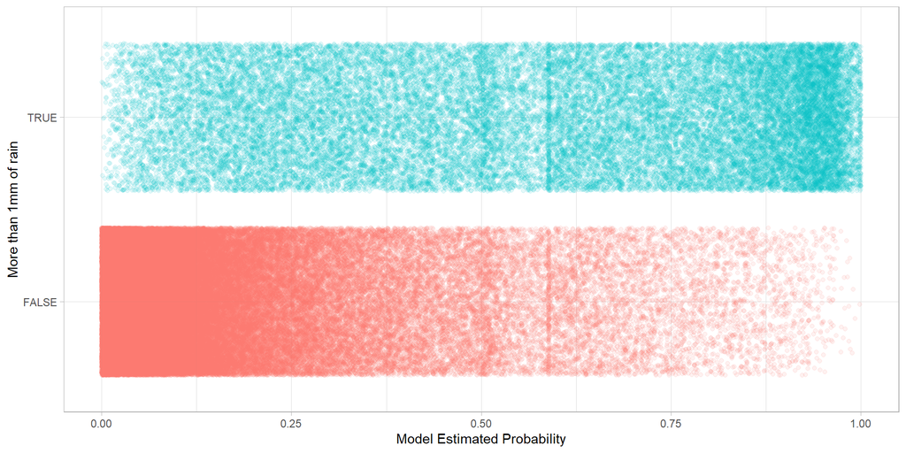

```r
rain %>%
  filter(RainTomorrow_Imputed == 0) %>%
  ggplot(aes(x = RainTomorrow_Prediction,
             y = RainTomorrow == 1,
             color = (RainTomorrow == 1))) +
  geom_jitter(alpha = 0.1, width = 0) +
  theme_light() +
  labs(y = "More than 1mm of rain", x = "Model Estimated Probability") +
  theme(legend.position = "none")
```

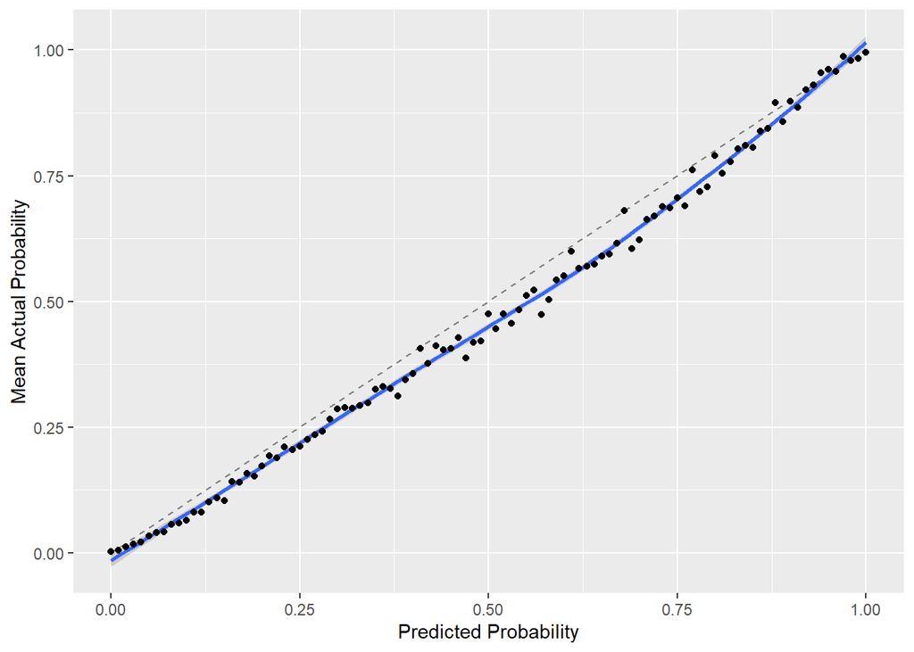

```r
rain %>%
  filter(RainTomorrow_Imputed == 0) %>%
  mutate(Prediction = round(RainTomorrow_Prediction*100)/100) %>%
  group_by(Prediction) %>%
  mutate(MeanActual = mean(RainTomorrow)) %>%
  ungroup() %>%
  distinct(Prediction, MeanActual, .keep_all = TRUE) %>%
  ggplot(aes(x = Prediction,
             y = MeanActual)) +
  geom_segment(x = 0, y = 0, xend = 1, yend = 1,
               linetype = "dashed", color = "gray50") +
  geom_smooth() +
  geom_point() +
  labs(x = "Predicted Probability",
       y = "Mean Actual Probability")
```

# Tweaking Results for Improved Accuracy

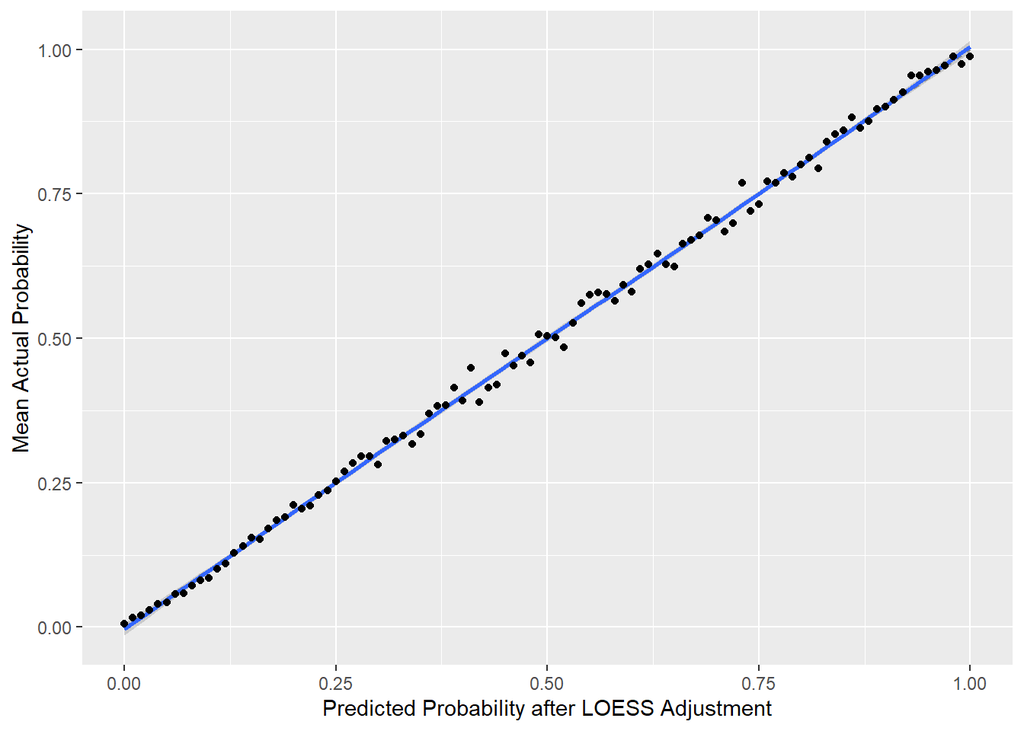

```r
smooth_pred <- rain %>%
  filter(RainTomorrow_Imputed == 0) %>%
  mutate(Prediction = round(RainTomorrow_Prediction*100)/100) %>%
  group_by(Prediction) %>%
  mutate(MeanActual = mean(RainTomorrow)) %>%
  ungroup() %>%
  distinct(Prediction, MeanActual, .keep_all = TRUE)

# See my document on LOESS curves. Locallized regression has a lot of uses.
smooth_model <- loess(MeanActual ~ Prediction, data = smooth_pred)

rain <- rain %>%
  mutate(RainTomorrow_AdjustedProbability =
           predict(smooth_model, newdata = rain$RainTomorrow_Prediction)
         ) %>%
  mutate(RainTomorrow_AdjustedProbability = case_when(
    # These are just estimates of what
    # 100% and up and 0% and below actually are:
    RainTomorrow_AdjustedProbability > 0.99997 ~ 0.99997,
    RainTomorrow_AdjustedProbability < 0.0002 ~ 0.0002,
    TRUE ~ RainTomorrow_AdjustedProbability))

rain %>%
  filter(RainTomorrow_Imputed == 0) %>%
  mutate(Prediction = round(RainTomorrow_AdjustedProbability*100)/100) %>%
  group_by(Prediction) %>%
  mutate(MeanActual = mean(RainTomorrow)) %>%
  ungroup() %>%
  distinct(Prediction, MeanActual, .keep_all = TRUE) %>%
  ggplot(aes(x = Prediction,
             y = MeanActual)) +
  geom_segment(x = 0, y = 0, xend = 1, yend = 1,
               linetype = "dashed", color = "gray50") +
  geom_smooth() +
  geom_point() +
  labs(x = "Predicted Probability after LOESS Adjustment",
       y = "Mean Actual Probability")
```

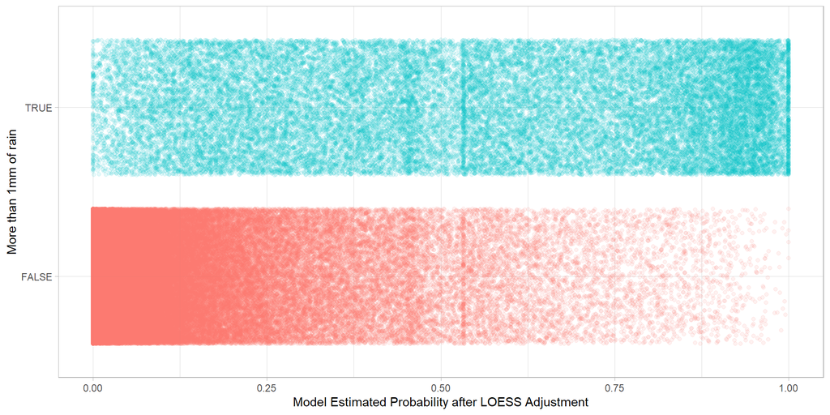

```r
rain %>%
  filter(RainTomorrow_Imputed == 0) %>%
  ggplot(aes(x = RainTomorrow_AdjustedProbability,
             y = RainTomorrow == 1,
             color = (RainTomorrow == 1))) +
  geom_jitter(alpha = 0.1, width = 0) +
  theme_light() +
  labs(y = "More than 1mm of rain",
       x = "Model Estimated Probability after LOESS Adjustment") +
  theme(legend.position = "none")
```

```r
rain %>% write_csv("rain_final_imputed.csv")
```

# Validation of LOESS Technique

```r
# Validate what we've done here
unimputed_rain <- rain %>%
  filter(RainTomorrow_Imputed == 0)

train_rows <- sample(1:nrow(unimputed_rain), round(0.75*nrow(unimputed_rain)))

smooth_pred_val <- unimputed_rain[train_rows,] %>%
  mutate(Prediction = round(RainTomorrow_Prediction*100)/100) %>%
  group_by(Prediction) %>%
  mutate(MeanActual = mean(RainTomorrow)) %>%
  ungroup() %>%
  distinct(Prediction, MeanActual, .keep_all = TRUE)

smooth_pred_val <- loess(MeanActual ~ Prediction, data = smooth_pred_val)

rain2 <- unimputed_rain %>%
  mutate(RainTomorrow_AdjustedProbability =
           predict(smooth_pred_val,
                   newdata = unimputed_rain$RainTomorrow_Prediction)
  ) %>%
  mutate(RainTomorrow_AdjustedProbability = case_when(
    # These are just estimates of what
    # 100% and up and 0% and below actually are.
    RainTomorrow_AdjustedProbability > 0.99997 ~ 0.99997,
    RainTomorrow_AdjustedProbability < 0.0002 ~ 0.0002,
    TRUE ~ RainTomorrow_AdjustedProbability))
```

Prediction accuracy on dataset A:

```r
mean(rain2[train_rows,]$RainTomorrow ==
       (rain2[train_rows,]$RainTomorrow_Prediction >= 0.5))
```

```
## [1] 0.8602841
```

Prediction accuracy on dataset B:

```r
mean(rain2[-train_rows,]$RainTomorrow ==
       (rain2[-train_rows,]$RainTomorrow_Prediction >= 0.5))
```

```
## [1] 0.8557725
```

Training LOESS adjusted prediction accuracy (dataset A):

```r
mean(rain2[train_rows,]$RainTomorrow ==
       (rain2[train_rows,]$RainTomorrow_AdjustedProbability >= 0.5))
```

```
## [1] 0.862047
```

Validation LOESS adjusted prediction accuracy (dataset B):

```r
mean(rain2[-train_rows,]$RainTomorrow ==
       (rain2[-train_rows,]$RainTomorrow_AdjustedProbability >= 0.5))
```

```
## [1] 0.85611
```

I do realize that the LOESS adjustment was validated on a different selection from the deep learning validation. I have reason to believe this has made little difference, but I fix it in the “Improvement” section.

# Improvement

Initially, I filtered to the first imputed data set as a test but I meant to use all 10 datasets for training eventually, so I’ll do that now.

Since the data is 10 times the size, I reduced the `patience` argument from 25 to 20. I also decreased the maximum number of epochs, but this didn’t make a difference; in both cases the maximum was not reached.

So unfortunately, since I also changed the patience parameter, the effects of a larger training set are confounded with it. I didn’t do any scaling, which is preferred for comparing the results.

### Get Predictions

```r
# *Starting with a fresh R session*
library(tidyverse)
library(tensorflow)
library(keras)

rain <- read_csv("bb_rain.csv")

# # Take single dataset to test
# rain <- rain %>%
#   filter(.imp == 1, RainTomorrow_Imputed == 0) %>%
#   select(-c(.imp, .id))

# Now using all data
rain <- rain %>%
  filter(RainTomorrow_Imputed == 0) %>%
  select(-c(.imp, .id))

# Null error rate, 0.7758188
sum(rain$RainTomorrow == 0)/nrow(rain)

# Removing the same rows from each .imp
train_rows <- sample(1:(nrow(rain)/10), round(nrow(rain)/10*0.85)) %>%
  rep(10)
# Preserve so we don't loose this:
write_rds(train_rows, "final_model_train_rows.rds")

# Get sets
X <- rain %>% select(-RainTomorrow, -RainTomorrow_Imputed)
y <- rain %>% select(RainTomorrow)
X_train <- X[train_rows,]
y_train <- y[train_rows,]
X_test <- X[-train_rows,]
y_test <- y[-train_rows,]


inputs <- layer_input(shape = c(50))
outputs <- inputs %>%
  layer_dense(50, activation = 'elu') %>%
  layer_dense(25, activation = 'elu') %>%
  layer_dense(13, activation = 'elu') %>%
  layer_dense(6, activation = 'elu') %>%
  layer_dense(1, activation = 'sigmoid')

model <- keras_model(inputs = inputs, outputs = outputs)
model %>% compile(
  optimizer = 'adam',
  loss = 'binary_crossentropy',
  metrics = c('accuracy'))

model %>% fit(
  as.matrix(X_train),
  as.matrix(y_train),
  validation_data = list(
    as.matrix(X_test),
    as.matrix(y_test)),
  epochs = 100, # These parameters are reduced because there's much more data.
  callbacks = list(
    callback_early_stopping(
      monitor = 'val_loss',
      mode = 'min',
      patience = 20)))

rain_complete <- read_csv("bb_rain.csv")
X_complete <- rain_complete %>%
  select(-.imp, -.id, -RainTomorrow, -RainTomorrow_Imputed)

y_pred <- model %>% predict(as.matrix(X_complete))
rain_complete$RainTomorrow_Prediction <- as.vector(y_pred)

write_csv(rain_complete, "results_final.csv")
```

### Observe Results and Apply LOESS Adjustment

```r
# *May or may not clean up environment before proceeding*
library(tidyverse)
```

```r
rain <- read_csv("results_final.csv")
```

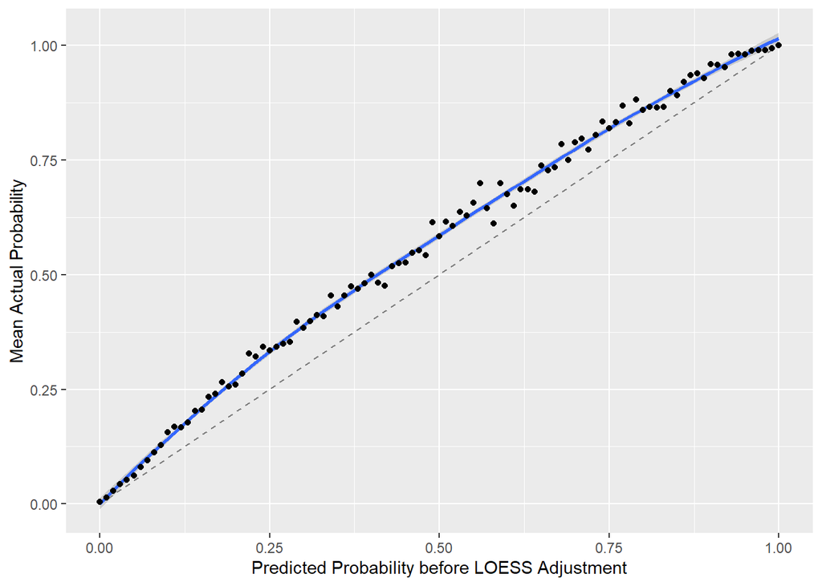

```r
rain <- rain %>%
  group_by(.id) %>%
  mutate(RainTomorrow_Prediction = mean(RainTomorrow_Prediction)) %>%
  filter(.imp == 1) %>%
  ungroup()

# # Not that this isn't interesting, but it's not so different from the adjusted
# # version.
# rain %>%
#   filter(RainTomorrow_Imputed == 0) %>%
#   ggplot(aes(x = RainTomorrow_Prediction,
#              y = RainTomorrow == 1,
#              color = (RainTomorrow == 1))) +
#   geom_jitter(alpha = 0.1, width = 0) +
#   theme_light() +
# labs(y = "More than 1mm of rain",
#      x = "Model Estimated Probability before LOESS Adjustment") +
# theme(legend.position = "none")

rain %>%
  filter(RainTomorrow_Imputed == 0) %>%
  mutate(Prediction = round(RainTomorrow_Prediction*100)/100) %>%
  group_by(Prediction) %>%
  mutate(MeanActual = mean(RainTomorrow)) %>%
  ungroup() %>%
  distinct(Prediction, MeanActual, .keep_all = TRUE) %>%
  ggplot(aes(x = Prediction,
             y = MeanActual)) +
  geom_segment(x = 0, y = 0, xend = 1, yend = 1,
               linetype = "dashed", color = "gray50") +
  geom_smooth() +
  geom_point() +
  labs(x = "Predicted Probability before LOESS Adjustment",
       y = "Mean Actual Probability")
```

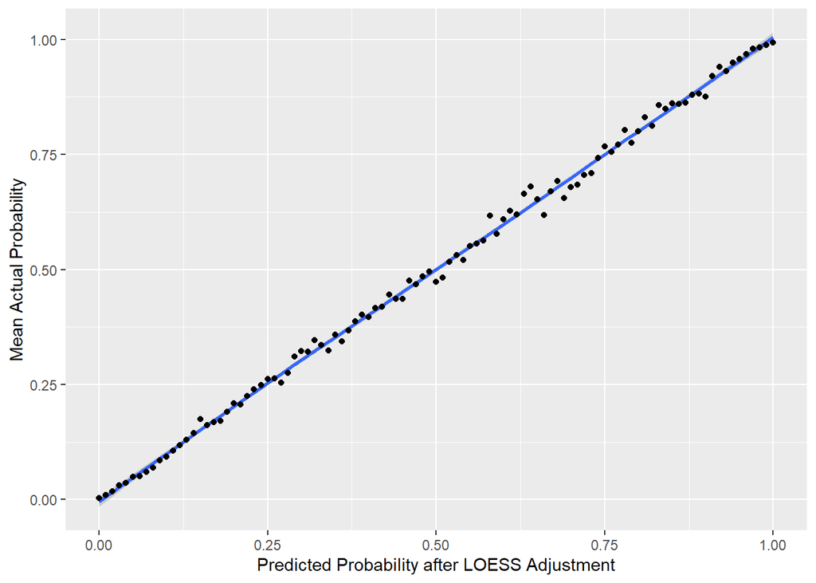

```r
smooth_pred <- rain %>%
  filter(RainTomorrow_Imputed == 0) %>%
  mutate(Prediction = round(RainTomorrow_Prediction*100)/100) %>%
  group_by(Prediction) %>%
  mutate(MeanActual = mean(RainTomorrow)) %>%
  ungroup() %>%
  distinct(Prediction, MeanActual, .keep_all = TRUE)

smooth_model <- loess(MeanActual ~ Prediction, data = smooth_pred)

rain <- rain %>%
  mutate(RainTomorrow_AdjustedProbability =
           predict(smooth_model, newdata = rain$RainTomorrow_Prediction)
         ) %>%
  # Not doing anything fancy this time.
  mutate(RainTomorrow_AdjustedProbability = case_when(
    RainTomorrow_AdjustedProbability > 1 ~ 1,
    RainTomorrow_AdjustedProbability < 0 ~ 0,
    TRUE ~ RainTomorrow_AdjustedProbability))

rain %>%
  filter(RainTomorrow_Imputed == 0) %>%
  mutate(Prediction = round(RainTomorrow_AdjustedProbability*100)/100) %>%
  group_by(Prediction) %>%
  mutate(MeanActual = mean(RainTomorrow)) %>%
  ungroup() %>%
  distinct(Prediction, MeanActual, .keep_all = TRUE) %>%
  ggplot(aes(x = Prediction,
             y = MeanActual)) +
  geom_segment(x = 0, y = 0, xend = 1, yend = 1,
               linetype = "dashed", color = "gray50") +
  geom_smooth() +
  geom_point() +
  labs(x = "Predicted Probability after LOESS Adjustment",
       y = "Mean Actual Probability")
```

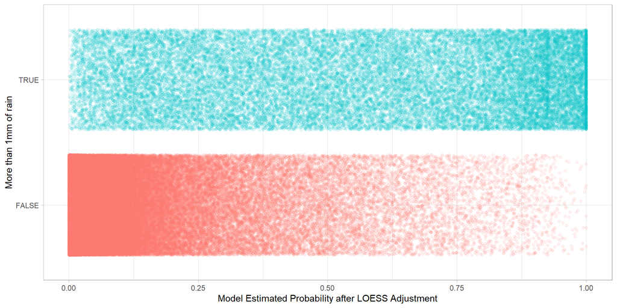

```r
rain %>%
  filter(RainTomorrow_Imputed == 0) %>%
  ggplot(aes(x = RainTomorrow_AdjustedProbability,
             y = RainTomorrow == 1,
             color = (RainTomorrow == 1))) +
  geom_jitter(alpha = 0.1, width = 0) +
  theme_light() +
  labs(y = "More than 1mm of rain",
       x = "Model Estimated Probability after LOESS Adjustment") +
  theme(legend.position = "none")
```

```r
# Validate LOESS
unimputed_rain <- rain %>%
  filter(RainTomorrow_Imputed == 0)

train_rows <- read_rds("final_model_train_rows.rds")

smooth_pred_val <- unimputed_rain[train_rows,] %>%
  mutate(Prediction = round(RainTomorrow_Prediction*100)/100) %>%
  group_by(Prediction) %>%
  mutate(MeanActual = mean(RainTomorrow)) %>%
  ungroup() %>%
  distinct(Prediction, MeanActual, .keep_all = TRUE)

smooth_pred_val <- loess(MeanActual ~ Prediction, data = smooth_pred_val)

rain2 <- unimputed_rain %>%
  mutate(RainTomorrow_AdjustedProbability =
           predict(smooth_pred_val,
                   newdata = unimputed_rain$RainTomorrow_Prediction)
  ) %>%
  mutate(RainTomorrow_AdjustedProbability = case_when(
    RainTomorrow_AdjustedProbability > 1 ~ 1,
    RainTomorrow_AdjustedProbability < 0 ~ 0,
    TRUE ~ RainTomorrow_AdjustedProbability))

# LOESS Training Accuracy
mean(rain2[train_rows,]$RainTomorrow ==
       (rain2[train_rows,]$RainTomorrow_AdjustedProbability >= 0.5))
```

```
## [1] 0.8650963
```

```r
# LOESS Validation Accuracy # This is technically THE validation accuracy
# for my entire project.
mean(rain2[-train_rows,]$RainTomorrow ==
       (rain2[-train_rows,]$RainTomorrow_AdjustedProbability >= 0.5))
```

```
## [1] 0.8662385
```

```r
# No LOESS train rows
mean(rain2[train_rows,]$RainTomorrow ==
       (rain2[train_rows,]$RainTomorrow_Prediction >= 0.5))
```

```
## [1] 0.8630113
```

```r
# No LOESS validation rows
mean(rain2[-train_rows,]$RainTomorrow ==
       (rain2[-train_rows,]$RainTomorrow_Prediction >= 0.5))
```

```
## [1] 0.8629097
```

```r
# Overall LOESS
mean(unimputed_rain[train_rows,]$RainTomorrow ==
       (unimputed_rain[train_rows,]$RainTomorrow_AdjustedProbability >= 0.5))
```

```
## [1] 0.8650549
```

```r
# Overall No LOESS
mean(unimputed_rain[train_rows,]$RainTomorrow ==
       (unimputed_rain[train_rows,]$RainTomorrow_Prediction >= 0.5))
```

```
## [1] 0.8630113
```

```r
# Overall with imputed RainTomorrow, LOESS
mean(rain[train_rows,]$RainTomorrow ==
       (rain[train_rows,]$RainTomorrow_AdjustedProbability >= 0.5))
```

```
## [1] 0.8613566
```

```r
# Overall with imputed RainTomorrow, no LOESS
mean(rain[train_rows,]$RainTomorrow ==
       (rain[train_rows,]$RainTomorrow_Prediction >= 0.5))
```

```
## [1] 0.8597184
```

```r
# Consistently, the adjustment improves accuracy.
```

The validation accuracy without the LOESS adjustment is 86.29%. The final validation accuracy, after applying the LOESS adjustment, is 86.62%. This is good. (And we’ve now validated LOESS correctly.)

# Comparing to Other Kaggle Results

Regardless of the method, most attempts that have been published on Kaggle achieve 85-86% accuracy. None of these I’ve seen use easily interpretable models. Even though others aren’t using the extra encoding that I performed in preprocessing with time of year, wind direction, location, and missing values, my results are not that much better. I do think the added piping to LOESS makes a meaningful difference.

The models I’ve seen that exceed 87% only made predictions on rows without missing data. Since I achieved 86.6%, a validation accuracy above 87% with rows that have missing values seems very possible.

Return